# INFS 691 - Homework8 - Part2

Text Mining and Sentiment Analysis

Rose Dunderdale

Read the document “Homework8 Instructions.docx” for detailed information about Homework 8 that has three parts.

In “Homework8.Part2”, you will carry out text mining and sentiment analysis for the text data “GuderRMP.txt”. This text data contains the actual reviews that the students posted on Rate My Professor (RMP) site for all the courses that I taught at Loyola. You need to perform all steps of text mining as was done in the example problem presented in the reading document and in the videos.

```r
install.packages("tm")
install.packages("dplyr")
install.packages("stringr")
install.packages("wordcloud")
install.packages("wordcloud2")
```

```
Error in install.packages : Updating loaded packages
```

```r
install.packages("syuzhet")
install.packages("tidytext")
install.packages("wordcloud2")
library(tm)  # major package for text mining
library(dplyr) # data manipulation
library(stringr) # for string-split
library(wordcloud)  # wordcloud generator
library(wordcloud2) # wordcloud2 generator
library(syuzhet) # sentiment lexicons
library(tidytext) # manipulation, sentiment
```

### Text Mining and Sentiment Analysis Process

#### Step 1. Read Data and Create Corpus

#### Step 2. Clean Data

#### Step 3. Create Term Document Matrix (tdm)

#### Step 4. Analyze Data

#### (word frequency and Sentiment Analysis)

#### Step 1. Read Text Data and Create Corpus

1. Read the text data Text data “GuderRMP.txt” contains the actual teacher/course evaluations for the course (INFS691) that I taught at Loyola University of Chicago (LUC) in the last 3 years.

```r
text0 <- readLines("GuderRMP.txt")
text0
# text0: A character vector with 196 elements.

# convert text0 to a character vector of one element (combine reviews)
text <- paste(text0, collapse=" ") # combine all in one text
text
```

2. Create corpus corpus is a data structure (list) that is used by the “tm” package to process and analyze text data

```r
corpus <- Corpus(VectorSource(text)) # corpus is a list of 2 elements
inspect(corpus) # or corpus$content to display the content of corpus
```

```
<<SimpleCorpus>>
Metadata:  corpus specific: 1, document level (indexed): 0
Content:  documents: 1

[1] Professor Guder is a solid professor. He is very accessible to his students and wants all his students to succeed.  I took this class online during the pandemic and it was asynchronous and only met a few times during the semester.  Workload is spread-out and he posted great video lectures and no…
```

```r
#result: the corpus has the same content as the text vector
```

#### Step 2. Clean Data (corpus)

Purpose: to understand and analyze opinions and feelings of the customers and take actions accordingly. Cleaning: removing data/words that do not reflect any opinions or feelings.

See the corpus (before cleaning)

```r
inspect(corpus)
```

[output not shown]

To clean data in corpus, we will use tm_map() function available in “tm” package

```r
# convert the text to lower case
corpus <- tm_map(corpus, tolower)
inspect(corpus) # to display the corpus
```

[output not shown]

```r
# remove english common stopwords (is, are, this, but, and, etc.)
corpus <- tm_map(corpus, removeWords, stopwords("english"))
inspect(corpus) # to display the corpus
```

[output not shown]

```r
# remove punctuation
corpus <- tm_map(corpus, removePunctuation) #removes punctuation
inspect(corpus) # to display the corpus
```

[output not shown]

```r
# remove additional words
#specified words: professor , guder, course, class
corpus <- tm_map(corpus, removeWords, c("professor", "guder", "course", "class"))
inspect(corpus) # to display the corpus
```

```
<<SimpleCorpus>>
Metadata:  corpus specific: 1, document level (indexed): 0
Content:  documents: 1

[1]  solid accessible students wants students succeed took online pandemic asynchronous met times semester workload spread posted great video lectures notes view anytime choose take unlike comments posted believe one best instructors mba program took time explain subject material provided lots learn…
```

```r
# remove numbers
corpus <- tm_map(corpus, removeNumbers)
inspect(corpus)
```

```
<<SimpleCorpus>>
Metadata:  corpus specific: 1, document level (indexed): 0
Content:  documents: 1

[1]  solid accessible students wants students succeed took online pandemic asynchronous met times semester workload spread posted great video lectures notes view anytime choose take unlike comments posted believe one best instructors mba program took time explain subject material provided lots learn…
```

```r
# Eliminate Whitespace
corpus <- tm_map(corpus, stripWhitespace)
inspect(corpus) # to display the corpus
```

```
<<SimpleCorpus>>
Metadata:  corpus specific: 1, document level (indexed): 0
Content:  documents: 1

[1]  solid accessible students wants students succeed took online pandemic asynchronous met times semester workload spread posted great video lectures notes view anytime choose take unlike comments posted believe one best instructors mba program took time explain subject material provided lots learn…
```

#### Create TWO objects: “text2” and “words”

```
(These objects will be used in Step 4 - Text analysis)
```

First object: text2 (1) text2: split the clean text (corpus) into individual elements (words) and assigns them to the vector “text2”. “Bag of words”.

```r
text2 <- str_split(corpus$content, pattern ="\\s+") # text2 is a list
text2 <- unlist(text2) #text2 is now a vector
#inspect(corpus)
text2
```

```
  [1] ""                "solid"           "accessible"      "students"        "wants"           "students"        "succeed"
  [8] "took"            "online"          "pandemic"        "asynchronous"    "met"             "times"           "semester"
 [15] "workload"        "spread"          "posted"          "great"           "video"           "lectures"        "notes"
 [22] "view"            "anytime"         "choose"          "take"            "unlike"          "comments"        "posted"
 [29] "believe"         "one"             "best"            "instructors"     "mba"             "program"         "took"
 [36] "time"            "explain"         "subject"         "material"        "provided"        "lots"            "learning"
 [43] "opportunities"   "grasp"           "concepts"        "tools"           "available"       "accomplish"      "analysis"
 [50] "homework"        "always"          "willing"         "meet"            "students"        "help"            "learn"
 [57] "convinced"       "dr"              "best"            "loyola"          "lectures"        "clear"           "concise"
 [64] "assignments"     "exams"           "straightforward" "ever"            "need"            "clarification"   "topic"
 [71] "tries"           "best"            "teach"           "way"             "will"            "successful"      "overall"
 [78] "phenomenal"      "caring"          "respected"       "must"            "take"            "quinlan"         "dr"
 [85] "ensures"         "work"            "grades"          "pay"             "attention"       "classes"         "homework"
 [92] "manage"          "good"            "grade"           "easily"          "lectures"        "homework"        "exams"
 [99] "well"            "organized"       "always"          "just"            "reach"           "difficult"       "go"
```

[output cut: 82 more lines]

```r
#Display text2
```

Second Object: words (2) words: the list of the words in text2 vector is is expressed in a data frame structure.

```r
words <- data.frame(word=text2)
words
```

| word |
| --- |
| solid |
| accessible |
| students |
| wants |
| students |
| succeed |
| took |
| online |
| pandemic |

[output cut: 665 more lines]

#### Step 3. Build a TermDocumentMatrix (tdm)

Text mining processes transforms unstructured text into a structured format (into a table/matrix) to identify meaningful patterns and new insights.

tdm turns the corpus into a document term matrix (structured data) Create tdm and the following objects: tdm_m, tdm_s, and tdm_df

```r
tdm <-TermDocumentMatrix(corpus) # tdm is a list
tdm_m <- as.matrix(tdm) # change td to matrix
tdm_m
# order the tdm_m matrix by decreasing value of frequencies
# and assign them to the vector "tdm_s"
tdm_s <- sort(rowSums(tdm_m), decreasing=TRUE)
tdm_s
# tdm_s is a vector
# convert the tdm_s vector into a data frame format (tdm_df)
# with the column names as follows:
# column1 is named as 'word', column2 is named as 'freq'
# This is needed only if you wanted to display wordcloud2 in step 4
tdm_df <- data.frame(word = names(tdm_s), freq=tdm_s)
tdm_df
```

#### Step 4. Analyze Text Data

1. Visual Display of word frequencies using wordcloud
2. Visual Display of word frequencies using barplot
3. Sentiment Analysis - calculate sentiments (customer opinions)

#### (1) Display word frequencies using wordcloud

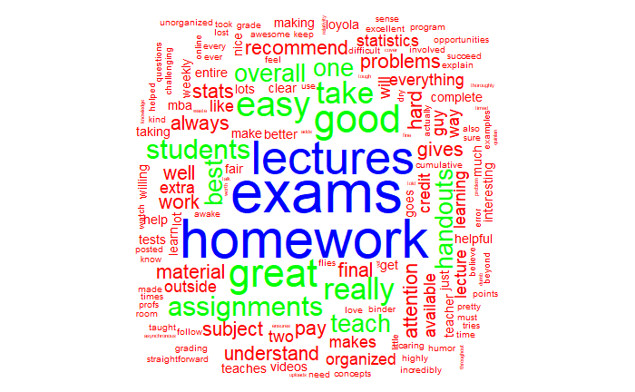

```r
# wordcloud (corpus)
set.seed(123)        # to obtain the same display
wordcloud(corpus,    #clean corpus
         max.words=150,  # max number of words
         min.freq=1,     # words with the frequency below will not be plotted
         random.order=F, # the words displayed in random order
         color=rainbow(3),  # rainbow color option
         scale=c(4.0,0.1),  # the range of the size of the words
         rot.per=0.30)      # proportion of the words to be rotated
```

Another package - wordcloud2 Using wordcloud2

```r
set.seed(123)
wordcloud2(tdm_df,
           size=0.6,
           color=rainbow(5),
           shape="oval",
           rotateRatio=0.3)
```

[interactive chart not shown]

#### (2) Display word frequencies using a barplot

Display barplot for the top 15 most frequent words

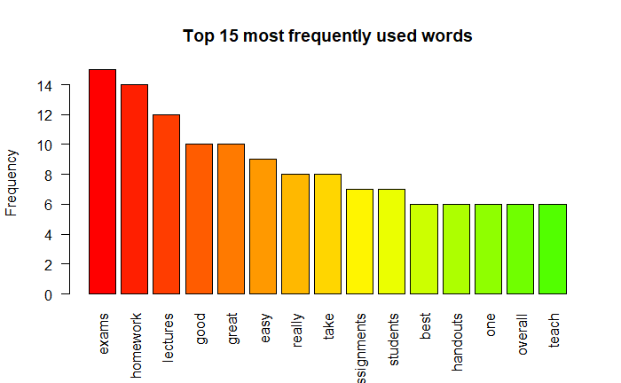

```r
# using the tdm_s: sorted tdms_s matrix
barplot(head(tdm_s,15),    # the object should be a (sorted) vector
        las=2,
        col=rainbow(50),
        ylab="Frequency",
        main= "Top 15 most frequently used words")
```

#### (3) Sentiment Analysis

# sentiment analysis = the process of determining whether a text is posituve,

# negative or neutral

#### Sentiment Scores using “bing” lexicon, which categorizes words into

# positive and negative categories

#### Read the lexicon by bing: list of positive and negative terms

Pull out only sentiment words. #### Read the sentiment words in the “bing” lexicon:

```r
bing <- get_sentiments(lexicon="bing") # from tidytext package
bing                                   # list of word in bing lexicon - 6786 words
```

| word | sentiment |
| --- | --- |
| 2-faces | negative |
| abnormal | negative |
| abolish | negative |
| abominable | negative |
| abominably | negative |
| abominate | negative |
| abomination | negative |
| abort | negative |
| aborted | negative |
| aborts | negative |

[output cut: 990 more lines]

```r
words                                  # list of (bag) words in clean opus -
```

| word |
| --- |
| solid |
| accessible |
| students |
| wants |
| students |
| succeed |
| took |
| online |
| pandemic |

[output cut: 665 more lines]

```r
                                       ## created in step 2
```

#### Determine the sentiment words in our text (corpus)

```r
text_bing <- inner_join(words, bing, by="word")
text_bing   # list of all sentiment words in clean corpus
```

| word | sentiment |
| --- | --- |
| solid | positive |
| accessible | positive |
| succeed | positive |
| great | positive |
| best | positive |
| available | positive |
| accomplish | positive |
| willing | positive |
| best | positive |
| clear | positive |

[output cut: 147 more lines]

Separate the list of the positive an negative words

```r
poswords <- subset(text_bing, sentiment=="positive")
negwords <- subset(text_bing, sentiment=="negative")
poswords    # display the positive words
```

|  | word | sentiment |
| --- | --- | --- |
| 1 | solid | positive |
| 2 | accessible | positive |
| 3 | succeed | positive |
| 4 | great | positive |
| 5 | best | positive |
| 6 | available | positive |
| 7 | accomplish | positive |
| 8 | willing | positive |
| 9 | best | positive |
| 10 | clear | positive |

[output cut: 112 more lines]

```r
negwords    # display the negative words
```

|  | word | sentiment |
| --- | --- | --- |
| 19 | difficult | negative |
| 21 | problems | negative |
| 22 | terrible | negative |
| 24 | dumb | negative |
| 25 | belittle | negative |
| 26 | error | negative |
| 31 | funny | negative |
| 40 | mistake | negative |
| 45 | lost | negative |
| 46 | hard | negative |

[output cut: 25 more lines]

Count the number of positive and negative and calculate the sentiment score for the text.

```r
countPos <- nrow(poswords)    # count the number of positive words
countNeg <- nrow(negwords)    # count the number of negative words
countPos
```

```
[1] 122
```

```r
countNeg
```

```
[1] 35
```

```r
# Calculate sentiment score (sentiment score = countPos - countNeg)
result <- c(positive=countPos, negative=countNeg, sentimentsScore=countPos - countNeg)
result
```

```
       positive        negative sentimentsScore
            122              35              87
```

This sentiment score indicates a very strong positive review by the students

### Note about the sentiment scores

The # of positive and negative sentiments, and the sentiment score depends on the number of reviews.

The # of the positive and negative words tend to increase together for a longer review. Therefore, it might be helpful to use the ratios of positive and negative word counts if you are comparing the sentiment scores for 2 different products or services with different number of reviews (texts), it might be helpful to use the ratios of the number of positive and negative words.

### results review

Degree of positivity/negativity = countPos/(countPos + countNeg)

Degree of positive = 122/157 = 77.7%, meaning that 77.7% of the sentiment words in the reviews are positive. This is a high percenttage of positive words.

OR

Degree of positivity = countPos/countNeg

This ratio is an example equal to 122/35 = 3.49, meaning that the reviews in this example included 3.49 positive words for each negative word. Again, this ratio indicates a very strong positive sentiment.

#### Create the html file and submit it on Sakai

You need to create the html file: After completing your Rmd file, you will execute all the chunks, save the file, and generate the html file containing the codes, outputs, and the answers.

To create the html file, complete the following steps:

Step 1. (After writing all the codes) Execute all chunks one by one starting from the first chunk (regardless of whether you executed the codes while writing your codes).

Step 2. Save your file->Save As…

Important: Please check the html file to make sure that it contains the R codes, outputs, and your answers. If not, repeat Step 1 and Step 2.

#### Create the html file and submit it on Sakai

You need to create the html file: After completing your Rmd file, you will execute all the chunks, save the file, and generate the html file containing the codes, outputs, and the answers.

To create the html file, complete the following steps:

Step 1. (After writing all the codes) Execute all chunks one by one starting from the first chunk (regardless of whether you executed the codes while writing your codes).

Step 2. Save your file->Save As…

Important: Please check the html file to make sure that it contains the R codes, outputs, and your answers. If not, repeat Step 1 and Step 2.

#### Create the html file and submit it on Sakai

You need to create the html file: After completing your Rmd file, you will execute all the chunks, save the file, and generate the html file containing the codes, outputs, and the answers.

To create the html file, complete the following steps:

Step 1. (After writing all the codes) Execute all chunks one by one starting from the first chunk (regardless of whether you executed the codes while writing your codes).

Step 2. Save your file->Save As…

If you have completed Step 1, then Step 2 will save your Rmd file, and (at the same time) it will create the html file on your working directory. You will attach and submit this html file on Sakai as your homework8-Part2.

Important: Please check the html file to make sure that it contains the R codes, outputs, and your answers. If not, repeat Step 1 and Step 2.